# Survey — Agreement-style Likert Plot (Final)

Author

Generated by Assistant

Published

2025-12-27

**R code**

```r
library(tidyverse)   # includes dplyr, ggplot2, tidyr, purrr, stringr, forcats, etc.
library(scales)
library(patchwork)   # combine plots with custom relative heights
library(sessioninfo)
```

**R code**

```r
# Read CSV (adjust path if needed)
df <- readr::read_csv("course_survey_responses.csv")

# Requested domain order (will be used to control facet/plot sequence)
domains <- c(
  "Helpfulness of generative AI for each use case",
  "Impact on learning",
  "Impact on metagenomics learning",
  "Code quality outcomes using AI",
  "Trust calibration",
  "Ethical alignment",
  "Inquiry & exploration",
  "\"Vibe code\" outcomes"
)

# find columns that match any domain substring
col_matches <- names(df)[sapply(names(df), function(nm) any(sapply(domains, function(d) str_detect(nm, fixed(d)))))]
if (length(col_matches) == 0) stop("No matching columns found. Check column names or adjust domain patterns.")
raw_help <- df %>% select(all_of(col_matches))
```

**R code**

```r
# helper to detect domain and extract item text inside brackets if present
detect_domain <- function(colname, domain_vec) {
  idx <- which(sapply(domain_vec, function(d) str_detect(colname, fixed(d))))
  if (length(idx) == 0) return(NA_character_)
  domain_vec[idx[1]]
}

col_info <- tibble(orig_name = names(raw_help)) %>%
  mutate(domain = map_chr(orig_name, ~ detect_domain(.x, domains)),
         item = if_else(str_detect(orig_name, "\\[.*\\]"),
                        str_extract(orig_name, "(?<=\\[).+?(?=\\])"),
                        str_remove(orig_name, fixed(domain))),
         item = str_trim(item),
         item = if_else(item == "" | is.na(item), orig_name, item))
col_info
```

```
# A tibble: 39 × 3
   orig_name                                                        domain item
   <chr>                                                            <chr>  <chr>
 1 Helpfulness of generative AI for each use case  [Suggesting R c… Helpf… Sugg…
 2 Helpfulness of generative AI for each use case  [Explaining R c… Helpf… Expl…
 3 Helpfulness of generative AI for each use case  [Improving code… Helpf… Impr…
 4 Helpfulness of generative AI for each use case  [Brainstorming … Helpf… Brai…
 5 Helpfulness of generative AI for each use case  [‘Vibe code’: g… Helpf… ‘Vib…
 6 Helpfulness of generative AI for each use case  [Data wrangling… Helpf… Data…
 7 Helpfulness of generative AI for each use case  [Understanding … Helpf… Unde…
 8 Helpfulness of generative AI for each use case  [Using RStudio … Helpf… Usin…
 9 Impact on learning [AI made learning R easier.]                  Impac… AI m…
10 Impact on learning [AI helped me understand R syntax and functi… Impac… AI h…
# ℹ 29 more rows
```

**R code**

```r
# Agreement levels and robust mapping function
agree_levels <- c("Strongly disagree", "Disagree", "Neutral", "Agree", "Strongly agree")

map_to_agree <- function(x) {
  x <- stringr::str_squish(as.character(x))
  x_lower <- tolower(x)
  case_when(
    # helpfulness -> agreement mapping
    x_lower %in% c("not at all helpful", "not helpful", "not at all helpful to not helpful") ~ "Strongly disagree",
    x_lower %in% c("slightly helpful") ~ "Disagree",
    x_lower %in% c("moderately helpful") ~ "Neutral",
    x_lower %in% c("very helpful") ~ "Agree",
    x_lower %in% c("extremely helpful") ~ "Strongly agree",
    # direct agreement variants
    x_lower %in% c("strongly disagree", "strong disagree") ~ "Strongly disagree",
    x_lower %in% c("disagree") ~ "Disagree",
    x_lower %in% c("neutral", "neither agree nor disagree", "neither") ~ "Neutral",
    x_lower %in% c("agree") ~ "Agree",
    x_lower %in% c("strongly agree", "strong agree") ~ "Strongly agree",
    # already canonical
    x %in% agree_levels ~ x,
    TRUE ~ NA_character_
  )
}

# pivot to long, join col_info, map responses, compute counts and percentages
long <- raw_help %>%
  pivot_longer(cols = everything(), names_to = "orig_name", values_to = "response_raw") %>%
  left_join(col_info, by = "orig_name") %>%
  mutate(response_mapped = map_to_agree(response_raw),
         response_mapped = factor(response_mapped, levels = agree_levels, ordered = TRUE)) %>%
  group_by(domain, item, response_mapped) %>%
  tally(name = "n") %>%
  group_by(domain, item) %>%
  mutate(pct = n / sum(n)) %>%
  ungroup()

# report any unmapped response variants
unmapped <- raw_help %>%
  pivot_longer(cols = everything(), names_to = "orig_name", values_to = "response_raw") %>%
  distinct(response_raw) %>%
  mutate(mapped = map_to_agree(response_raw)) %>%
  filter(is.na(mapped))

if (nrow(unmapped) > 0) {
  message("Unmapped response variants detected (consider adding mappings to map_to_agree):")
  print(unmapped$response_raw)
} else {
  message("No unmapped response variants detected based on current mapping.")
}
```

```
[1] "Stongly disagree"
```

**R code**

```r
# compute per-item positive proportion (Agree + Strongly agree) per domain
item_summary <- long %>%
  filter(!is.na(response_mapped)) %>%
  group_by(domain, item) %>%
  summarize(total_n = sum(n, na.rm = TRUE),
            positive_n = sum(n[response_mapped %in% c("Agree", "Strongly agree")], na.rm = TRUE),
            positive_pct = if_else(total_n > 0, positive_n / total_n, 0),
            .groups = "drop")
item_summary
```

```
# A tibble: 39 × 5
   domain                           item         total_n positive_n positive_pct
   <chr>                            <chr>          <int>      <int>        <dbl>
 1 "\"Vibe code\" outcomes"         AI-generate…      43         32        0.744
 2 "\"Vibe code\" outcomes"         I could cri…      43         21        0.488
 3 "\"Vibe code\" outcomes"         I understoo…      43         31        0.721
 4 "\"Vibe code\" outcomes"         I would be …      43         27        0.628
 5 "Code quality outcomes using AI" I relied on…      43         36        0.837
 6 "Code quality outcomes using AI" My analyses…      43         35        0.814
 7 "Code quality outcomes using AI" My code bec…      43         37        0.860
 8 "Code quality outcomes using AI" My code bec…      43         34        0.791
 9 "Code quality outcomes using AI" My code bec…      43         35        0.814
10 "Ethical alignment"              AI use enco…      43         26        0.605
# ℹ 29 more rows
```

**R code**

```r
# Prepare per-domain data frames (only domains present)
domain_dfs <- long %>%
  filter(!is.na(response_mapped)) %>%
  group_split(domain)
names(domain_dfs) <- map_chr(domain_dfs, ~ unique(.x$domain))

# keep only requested domains that actually exist in data
present_domains <- intersect(domains, names(domain_dfs))
domain_dfs <- domain_dfs[present_domains]

# count items per domain for relative heights
item_counts <- map_int(domain_dfs, ~ length(unique(.x$item)))

# color palette and common y-limits
cols <- c("Strongly disagree" = "#d73027",
          "Disagree" = "#fc8d59",
          "Neutral" = "#fee090",
          "Agree" = "#91bfdb",
          "Strongly agree" = "#1a9850")
y_limits <- c(0, 1)

# Build one ggplot per domain. Ensure scale_fill includes all five categories and uses a one-row legend.
plot_list <- imap(domain_dfs, function(df_dom, dom_name) {
  # determine ordering by positive_pct (descending), tie-break by total_n (descending)
  item_order <- item_summary %>%
    filter(domain == dom_name) %>%
    arrange(-desc(positive_pct), desc(total_n)) %>%
    pull(item)
  if (length(item_order) == 0) item_order <- unique(df_dom$item)

  df_dom2 <- df_dom %>%
    mutate(item = factor(item, levels = item_order, ordered = TRUE))

  ggplot(df_dom2, aes(x = item, y = pct, fill = response_mapped)) +
    geom_col(width = 0.75, color = NA) +
    coord_flip() +
    scale_y_continuous(labels = percent_format(accuracy = 1), limits = y_limits, expand = c(0,0)) +
    scale_fill_manual(values = cols,
                      breaks = agree_levels,
                      guide = guide_legend(nrow = 1, byrow = TRUE),
                      name = "Response") +
    labs(title = dom_name, x = NULL, y = NULL) +
    theme_minimal(base_size = 12) +
    theme(plot.title = element_text(size = 12, face = "bold", hjust = 0.5),
          axis.text.y = element_text(size = 10),
          panel.grid.major.y = element_blank(),
          plot.margin = margin(6,6,6,6),
          legend.position = "bottom")   # keep legend present for collection
})
```

**R code**

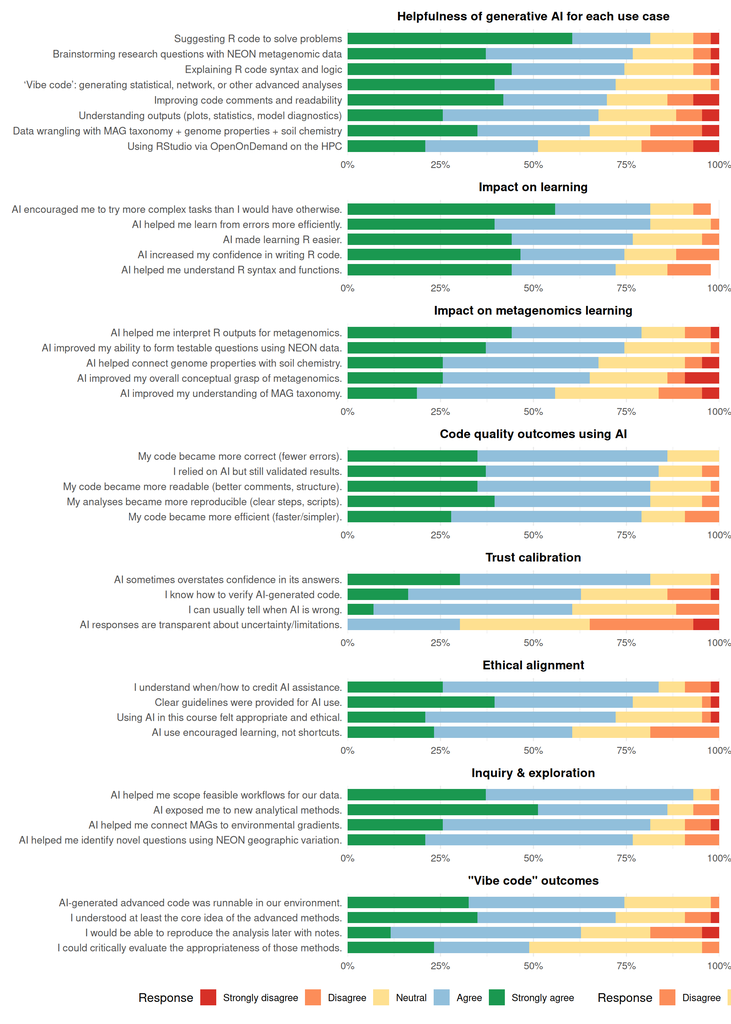

```r
# Combine vertically with a single collected legend at bottom
combined <- wrap_plots(plot_list, ncol = 1, guides = "collect") +
  plot_layout(heights = item_counts, guides = "collect") & theme(legend.position = "bottom")

print(combined)
```

Session info

```
 setting  value
 version  R version 4.4.1 (2024-06-14)
 os       Ubuntu 24.04.3 LTS
 system   x86_64, linux-gnu
 ui       X11
 language (EN)
 collate  en_US.UTF-8
 ctype    en_US.UTF-8
 tz       America/New_York
 date     2025-12-27
 pandoc   3.4 @ /usr/lib/rstudio/resources/app/bin/quarto/bin/tools/x86_64/ (via rmarkdown)
 quarto   1.6.42 @ /usr/lib/rstudio/resources/app/bin/quarto/bin/quarto
```

Notes - Items in each domain are ordered by positive_pct (Agree + Strongly agree) descending; ties broken by total responses. If you prefer a different tie-break or a manual ordering for a specific domain, tell me which domain and the exact item order. - The scale_fill_manual(breaks = agree_levels) ensures the legend shows all five response categories in the specified order. If a category has zero observations it will still appear in the legend. - Per-item bar thickness is kept consistent by assigning each domain a relative height equal to its item count in plot_layout(heights = item_counts). Adjust the heights multiplier if you want thicker/thinner bars (e.g., heights = item_counts * 1.2).

If you’d like, I can knit this Rmd for you and return the self-contained HTML file.

Below is a self-contained R chunk you can insert into your existing Rmd (after you read the CSV). It makes a single horizontal stacked bar — the same style & colors used before — showing the distribution of responses from the column

Did you become more engaged or interactive in solving problems using AI?

The chunk: - maps engagement text to the five agreement-style levels (so it uses your existing color scheme), - computes proportions, - draws one horizontal stacked bar with the same legend/colors.

Insert this after the code that defines df (or anywhere after the mapping functions are defined). If you want this as its own small plot file instead of inside the main Rmd, you can run the code in a separate R script — it is self-contained.

**R code**

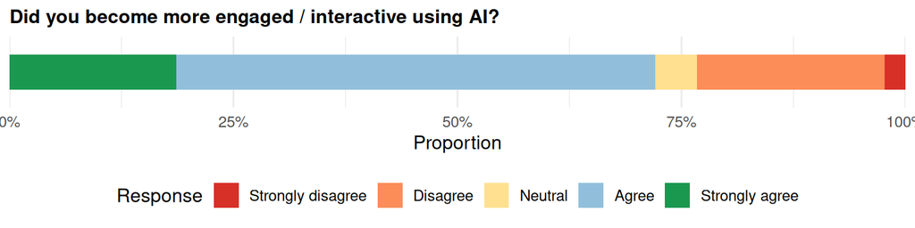

```r
library(tidyverse)
library(scales)

eng_col <- "Did you become more engaged or interactive in solving problems using AI?"

if (!eng_col %in% names(df)) stop(paste0("Column not found: ", eng_col))

eng_raw <- df %>%
  select(all_of(eng_col)) %>%
  rename(response_raw = all_of(eng_col)) %>%
  mutate(response_raw = stringr::str_squish(as.character(response_raw)))

# mapping to agreement-style levels (adjust variants as needed)
agree_levels <- c("Strongly disagree", "Disagree", "Neutral", "Agree", "Strongly agree")
eng_map <- function(x) {
  x_lower <- tolower(x)
  dplyr::case_when(
    x_lower %in% c("much more engaged", "much more engaged ") ~ "Strongly agree",
    x_lower %in% c("slightly more engaged", "slightly more engaged ") ~ "Agree",
    x_lower %in% c("no change", "neither more nor less", "no change ") ~ "Neutral",
    x_lower %in% c("slightly less engaged", "slightly less engaged ") ~ "Disagree",
    x_lower %in% c("much less engaged", "much less engaged ") ~ "Strongly disagree",
    x %in% agree_levels ~ x,
    TRUE ~ NA_character_
  )
}

# Count responses in character space to avoid factor/ordered factor joins
eng_counts <- eng_raw %>%
  mutate(response_mapped = eng_map(response_raw)) %>%   # keep as character for now
  count(response_mapped, name = "n")

# Ensure all five levels present (left join), then compute pct using a scalar total
eng_complete <- tibble(response_mapped = agree_levels) %>%
  left_join(eng_counts, by = "response_mapped") %>%
  replace_na(list(n = 0)) %>%
  mutate(response_mapped = factor(response_mapped, levels = agree_levels))

total_n <- sum(eng_complete$n)
eng_complete <- eng_complete %>%
  mutate(pct = if (total_n > 0) n / total_n else 0)

# color palette (matches your other plots)
cols <- c("Strongly disagree" = "#d73027",
          "Disagree" = "#fc8d59",
          "Neutral" = "#fee090",
          "Agree" = "#91bfdb",
          "Strongly agree" = "#1a9850")

# Single horizontal stacked bar (label as "Engagement")
p_eng <- eng_complete %>%
  mutate(label = "Engagement") %>%
  ggplot(aes(x = label, y = pct, fill = response_mapped)) +
  geom_col(width = 0.6, color = NA) +
  coord_flip() +
  scale_y_continuous(labels = percent_format(accuracy = 1), limits = c(0,1), expand = c(0,0)) +
  scale_fill_manual(values = cols, breaks = agree_levels, name = "Response",
                    guide = guide_legend(nrow = 1, byrow = TRUE)) +
  labs(x = NULL, y = "Proportion", title = "Did you become more engaged / interactive using AI?") +
  theme_minimal(base_size = 12) +
  theme(axis.text.y = element_blank(),
        axis.ticks.y = element_blank(),
        plot.title = element_text(size = 12, face = "bold"),
        legend.position = "bottom")

print(p_eng)
```

**R code**

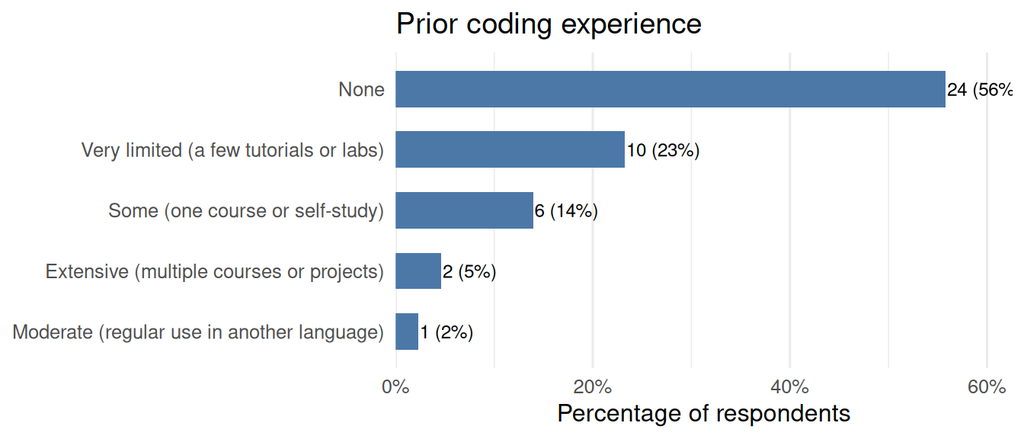

```r
library(tidyverse)
library(scales)

col_name <- "Prior coding experience"

if (!col_name %in% names(df)) stop(paste0("Column not found: ", col_name))

pc <- df %>%
  transmute(resp = stringr::str_squish(as.character(.data[[col_name]]))) %>%
  mutate(resp = if_else(resp == "" | is.na(resp), "<missing>", resp)) %>%
  count(resp, name = "n") %>%
  arrange(desc(n)) %>%
  mutate(pct = n / sum(n),
         resp = forcats::fct_reorder(resp, n))  # order by frequency

# Plot: horizontal bars with count + percent at end of each bar
ggplot(pc, aes(x = resp, y = pct)) +
  geom_col(fill = "#4C78A8", width = 0.6) +
  coord_flip() +
  scale_y_continuous(labels = percent_format(accuracy = 1), expand = expansion(mult = c(0, 0.12))) +
  geom_text(aes(label = paste0(n, " (", scales::percent(pct, accuracy = 1), ")")),
            hjust = -0.02, size = 3.2) +
  labs(title = "Prior coding experience",
       x = NULL, y = "Percentage of respondents") +
  theme_minimal(base_size = 12) +
  theme(panel.grid.major.y = element_blank())
```

**R code**

```r
library(tidyverse)

# read data if df not already in memory
if (!exists("df")) df <- readr::read_csv("course_survey_responses.csv")

cols <- c(
  "Overall effectiveness of AI in this course",
  "Likelihood to recommend AI use in similar courses"
)

res <- df %>%
  select(any_of(cols)) %>%
  pivot_longer(everything(), names_to = "column", values_to = "value") %>%
  mutate(value = as.numeric(value)) %>%                # convert to numeric
  group_by(column) %>%
  summarise(
    mean = mean(value, na.rm = TRUE),
    sd   = sd(value, na.rm = TRUE),
    n    = sum(!is.na(value)),
    .groups = "drop"
  ) %>%
  mutate(mean = round(mean, 2), sd = round(sd, 2))

print(res)
```

```
# A tibble: 2 × 4
  column                                             mean    sd     n
  <chr>                                             <dbl> <dbl> <int>
1 Likelihood to recommend AI use in similar courses  7.86  1.98    43
2 Overall effectiveness of AI in this course         8.6   1.22    43
```